# Santa Clara River Phenology

{Kristina Glass}

2023-12-15

# Introduction

*Credit: This project is based on materials developed by Chris Kibler

## What is Phenology

Phenology is the cyclical and seasonal lifecycle of natural phenomenon. For plants, importent phenological events include their growth of leaves, flowering, and death of leaves (or senescence). Some common phenological strategies of plants include the loss of leaves in winter and growth of leaves in spring (winter deciduous), the loss of leaves in summer (drought deciduous), and the maintenance of leaves year-round (evergreen). Due to climate change, plant phenology is shifting and it is important to understand what these shifts include and where these shifts are happening.

## Area of Interest

For this study, we’re interested in exploring plant phenology near the Santa Clara River which flows from Santa Clarita, CA and Ventura, CA. It is the last major coastal system within Southern California that has been relatively unchanged by development and supports over 17 species. The Santa Clara River is also supportive of one of the most valuable agricultural in the world[1](http://rivrlab.msi.ucsb.edu/santa-clara-river).

# Purpose of Study

The purpose of this study is to investigate plant phenology of riparian forests, grasslands, and chaparral shrub lands along the Santa Clara River. Riparian forests grow along the river and are dominated by winter deciduous cottonwood and willow trees, grasslands grow in open spaces and are predominate dominated by deciduous grasses, and chaparral shrub lands grow in more arid areas and are dominated by evergreen shrubs.

We will explore the vegetation productivity (NDVI), calculate the NDVI throughout the year, summarize the NDVI values within vegetation communities, and visualize the changes in NDVI within vegetation communities.

# Data

**Landsat Operational Land Imager (OLI sensor)** which contains 8 pre-processed scenes. The attributes of the scenes are as follows:

1. Level 2 surface reflectance products
2. erroneous values were set to NA
3. Scale factor set to 100
4. Bands are 2-7
5. Dates of the scenes are in file name

and

**Study sites** which are polygons that represent the sites of interest. The attributes are as follows:

1. “study_site” is a character string with plant type

The data are available in a folder labeled “data” within the repository

# Workflow

```r
library(terra)
library(sf)
library(dplyr)
library(tidyr)
library(stringr)
library(ggplot2)
library(here)
library(tmap)
library(cowplot)

rm(list = ls())
here::i_am("assignments/santa_clara_river_phenology/river_phenology.Rmd")
```

## Function to Compute Single NDVI Scene

This function computes the Normalized Difference Vegetation Index (NDVI). NDVI is a computation of the differences in reflectance (the ratio of incoming light reflected by a leaf) in NIR (near infrared) and red bands that are then normalized by sum

```r
# create function to compute single NDVI scene
ndvi_fun <- function(nir, red){

  (nir - red)/(nir + red)

}
```

```r
# read in first landsat scene from June 12, 2018
landsat_20180612 <- rast(here("assignments", "santa_clara_river_phenology","data", "landsat_20180612.tif"))
#view dataset
#landsat_20180612
#update layer names
names(landsat_20180612) <- c("blue", "green", "red", "NIR", "SWI1", "SWI2")
#confirm layer names were updated
#landsat_20180612
```

The NDVI function created above can be applied with the `lapp()` function, which applies a function to each cell using layers as arguments. To do so, the layers need to be passed into the function. For this data, NIR is the 4th layer and the red band is the 3rd. Bands or layers need to be applied in the order in which they were defined in the function.

```r
#compute NDVI for June 12th, 2018 with lapp()
ndvi_20180612<-lapp(landsat_20180612[[c(4,3)]], fun = ndvi_fun)
#view dataset
ndvi_20180612
```

```
## class       : SpatRaster
## dimensions  : 284, 1314, 1  (nrow, ncol, nlyr)
## resolution  : 30, 30  (x, y)
## extent      : 314415, 353835, 3803175, 3811695  (xmin, xmax, ymin, ymax)
## coord. ref. : WGS 84 / UTM zone 11N (EPSG:32611)
## source(s)   : memory
## name        :       lyr1
## min value   : -0.4089055
## max value   :  0.9304582
```

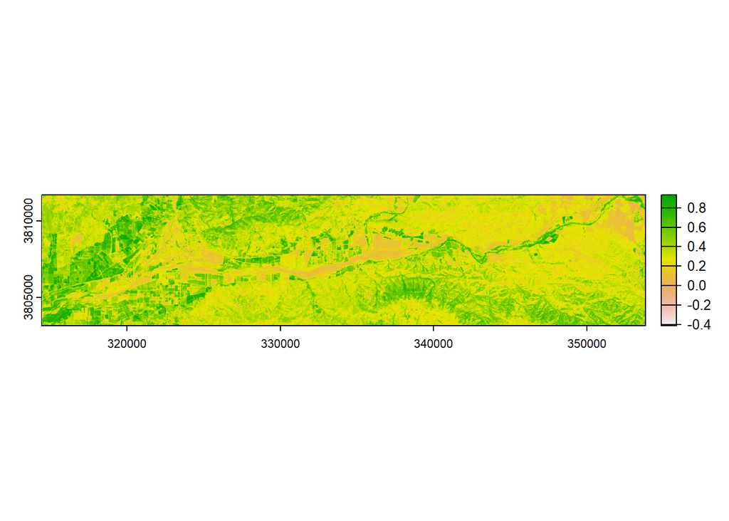

```r
#exploratory output plot of dataset
plot(ndvi_20180612)
```

## Function to Compute all NDVI Scenes

To make a more fluid process to compute NDVI, I created a function that computes all NDVI scenes simultaneously

```r
rm(list = ls())
here::i_am("assignments/santa_clara_river_phenology/river_phenology.Rmd")
```

```
## here() starts at C:/Users/krist/Documents/Meds/Courses/EDS223
```

```r
ndvi_fun = function(nir, red){
  (nir - red) / (nir + red)
}
```

```r
# create a basic outline of the function
# note: this code is not meant to run! we're just outlining the function we want to create
create_ndvi_layer <- function(){
  landsat <- rast(file) # read in scene
  names(landsat) <- c("blue", "green", "red", "NIR", "SWIR1", "SWIR2") # rename layers
  ndvi <- lapp(landsat[[c(4, 3)]], fun = ndvi_fun) # compute NDVI
}
```

```r
#calling for a list if files from the data folder stores all data to one variable
# the "pattern" option returns names that end in .tif (the file extension for the landsat scences)
# the "full.names" option returns the full file path for each scene

files <- list.files(here("assignments", "santa_clara_river_phenology","data"), pattern = "*.tif", full.names = TRUE)
```

```r
#update function to work with list of file names
# now we're passing our function a number that will correspond to the index in the list of file names
create_ndvi_layer <- function(i){
  landsat <- rast(files[i])
  names(landsat) <- c("blue", "green", "red", "NIR", "SWIR1", "SWIR2")
  ndvi <- lapp(landsat[[c(4, 3)]], fun = ndvi_fun)
}

#testfunction by asking it to read in the first file
test <- create_ndvi_layer(1)
```

```r
#run function on all scenes
# create NDVI layer for each scene (day) and stack into a single rasterstack
all_ndvi <- c(create_ndvi_layer(1),
              create_ndvi_layer(2),
              create_ndvi_layer(3),
              create_ndvi_layer(4),
              create_ndvi_layer(5),
              create_ndvi_layer(6),
              create_ndvi_layer(7),
              create_ndvi_layer(8))

# update layer names to match date
names(all_ndvi) <- c("2018-06-12",
                     "2018-08-15",
                     "2018-10-18",
                     "2018-11-03",
                     "2019-01-22",
                     "2019-02-23",
                     "2019-04-12",
                     "2019-07-01")
```

## Compare NDVI Across Vegetation Communities

Since the NDVI for each scene was computed, I can now compare changes in NDVI values across the vegetation communities within the region. As a reminder, those communities are: riparion forests, grasslands, chaparral shrub lands

Now that we have computed NDVI for each of our scenes (days) we want to compare changes in NDVI values across different vegetation communities.

```r
#read in shapefile of the study sites
sites <- st_read(here("assignments", "santa_clara_river_phenology","data", "study_sites.shp"))
```

```
## Variable(s) "col" contains positive and negative values, so midpoint is set to 0. Set midpoint = NA to show the full spectrum of the color palette.
```

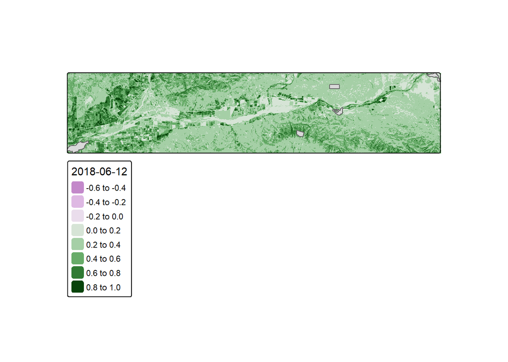

```r
# plot study sites on a single NDVI layer
tm_shape(all_ndvi[[1]]) +
  tm_raster() +
  tm_shape(sites) +
  tm_polygons()
```

Here we find the average NDVI within each study site. The output of extract is a data frame with rows that match the study site dataset, so we bind the results to the original dataset.

```r
#extract NDVI at Study Sites
#find average NDVI within each study sites
sites_ndvi <- terra::extract(all_ndvi, sites, fun = "mean")
#output of sites_ndvi will be a data frame that has rows that match the study sites data set

#bind both datasets by column
sites_annotated <- cbind(sites, sites_ndvi)

#clean dataset
sites_clean <- sites_annotated %>%
  st_drop_geometry() %>% #remove unecessary geometry
  select(-ID) %>% #remove ID column
  pivot_longer(!study_site) %>% #increases number or rows and decreases number of columns
  rename("NDVI" = value) %>% #rename column
  mutate("year" = str_sub(name, 2, 5), #extracts and replaces elements at a single position. finds emelent position within column and places it into new columns labled by year, month, day
         "month" = str_sub(name, 7, 8),
         "day" = str_sub(name, -2, -1)) %>%
  unite("date", 4:6, sep = "-") %>% #mutated columns above are brought into a single date column, separated by "-"
  mutate("date" = lubridate::as_date(date)) %>% #turn date column into a datetime object
  select(-name) #remove names column
```